# Hosmer-Lemeshow Model Calibration

Hao He, Yanhan Si

November 25, 2020

# Introduction

The purpose of this tutorial is to introduce the Hosmer-Lemeshow Test, which is a goodness of fit test for logistic regression models. We will first introduce the key concepts behind logistic regression models and the Hosmer-Lemeshow Test. Then we will use a bank churn data to illustrate how to perform Hosmer-Lemeshow test and create Hosmer-Lemeshow plot. Eventually we will compare the result to a likelihood based approach like AIC and explain the potential limitations with the HL test. We will provide step-by-step procedures in both **R** and **Stata**.

## Logistic Regression Model

Logistic regression is a statistical model that in its basic form uses a logistic function to model a binary response variable. In our example, the response variable will be whether the customer churn or not. Let’s denote the response variable to have value 0 or 1 in our case. The logistic model predicts $P(Y=1) = \frac{1}{1+exp(\beta'x)}$, so $P(Y=0) =\frac{exp(\beta'x)}{1+exp(\beta'x)}$.

## Hosmer-Lemeshow Test

The Hosmer-Lemeshow test (HL test) is a goodness of fit test for logistic regression, especially for risk prediction models. Specificially, HL test assesses whether or not the observed event rates match expected event rates in subgroups of the model population. This test is only used for binary response varibales(exited or retained in this example).

The Hosmer–Lemeshow test statistic is given by:
$$H = \sum_{g=1}^{G}\frac{(O_{1g}-E_{1g})^2}{N_g\pi_g(1-\pi_g)}$$
where $O_{1g}$, $E_{1g}$, $O_{0g}$, $E_{0g}$, $N_g$, and $π_g$ denote the observed $Y=1$ events, expected $Y=1$ events, observed $Y=0$ events, expected $Y=0$ events, total observations, predicted risk for the $g^{th}$ risk decile group, and G is the number of groups. The test statistic asymptotically follows a $\chi ^{2}$ distribution with G − 2 degrees of freedom.

For the HL test, the null hypothesis is that the observed and expected proportions are the same across subgroups, which indicates a good fit model. Like most goodness of fit tests, small p-values indicate a poor fit.

## Data Description

We will use the bank churn data available from Kaggle([Data Source](https://www.kaggle.com/shrutimechlearn/churn-modelling)). The data contains 10000 observations of 14 variables of which 2000 are positive observations. For simplicity, we only construct the logistic model using the variables below:

- `Credit Score`: The credit score of the customer, ranging from 350 to 850.
- `Geography`: The country where the customer belongs, including Germany, France and Spain.
- `Gender`: Female or Male.
- `Age`: Age of the customer.
- `Tenure`: Number of years for which the customer has been with the bank.
- `Balance`: Bank balance of the customer.
- `NumOfProducts`: Number of bank products the customer is utilising.
- `HasCrCard`: Binary Flag for whether the customer holds a credit card with the bank or not.
- `IsActiveMember`: Binary Flag for whether the customer is an active member with the bank or not.
- `EstimatedSalary`: Estimated salary of the customer in Dollars.
- `Exited`: The response variable indicated whether the customer churn or not. 1 means customer exited and 0 means retained.

## Software/Tools

In this tutorial, we are using R and STATA to show how Logistic Regression and Hosmer-Lemeshow Test could be implemented.

| Software | Relevant Libraries |
| --- | --- |
| R | `tidyverse` (data manipulation), `jtools` (model summary), `ResourceSelection` (Hosmer-Lemeshow Goodness Of Fit test), `modEvA` (Hosmer-Lemeshow plot) |
| STATA | `hl` (Hosmer-Lemeshow Goodness Of Fit test) |

# Data Visualization

```r
library(tidyverse)
library(jtools) # For printing model summary
library(ResourceSelection) # For Hosmer-Lemeshow Goodness Of Fit test
library(modEvA) # For Hosmer-Lemeshow plot

path = "./data"
file_name = sprintf('%s/Churn_Modelling_Cleaned.csv', path)
data = read.csv(file_name)

data = data %>% mutate(Exited = as.factor(Exited),
                       HasCrCard = as.factor(HasCrCard),
                       IsActiveMember = as.factor(IsActiveMember))
```

- Figure 1 shows the distributions of credit score and estimated salary stratified by the response variable `Exited` status. There is no vast difference between these two groups in terms of the credit scores distribution and estimated salary.

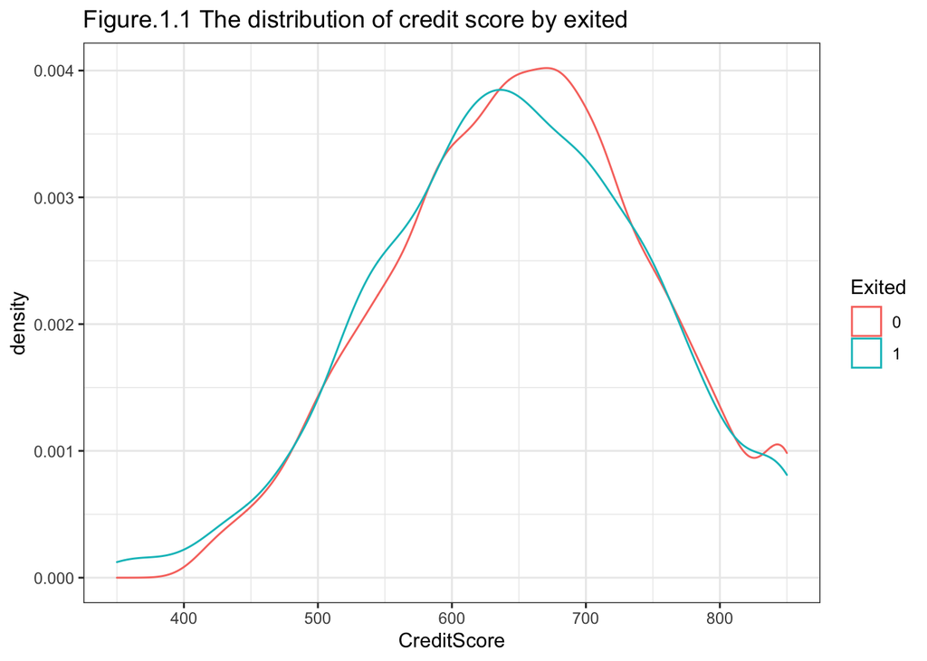

```r
data %>%
  ggplot(aes( CreditScore, color = Exited )) +
  geom_density() +
  ggtitle("Figure.1.1 The distribution of credit score by exited") +
  theme_bw()
```

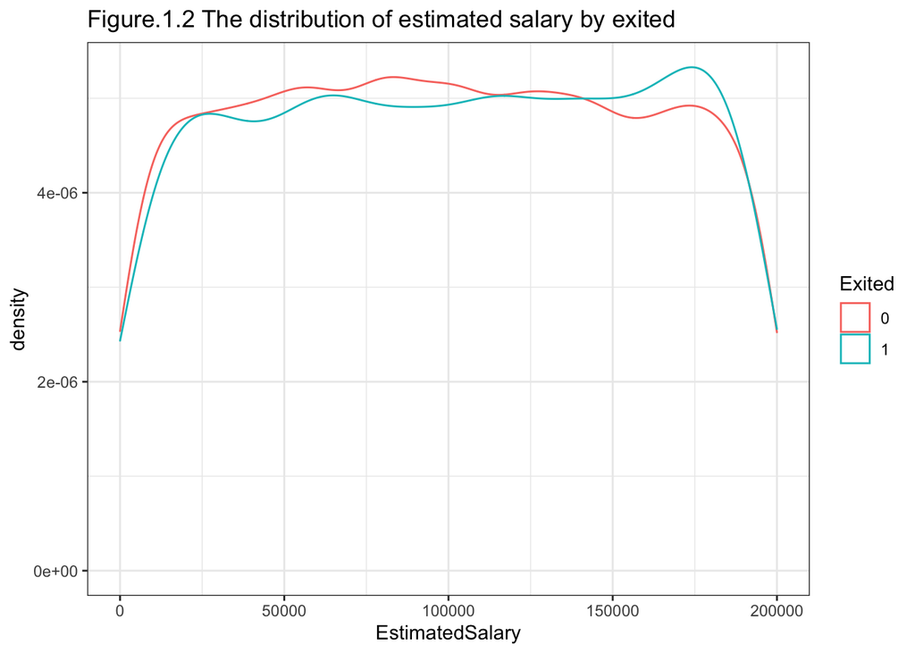

```r
data %>%
  ggplot(aes( EstimatedSalary, color = Exited )) +
  geom_density() +
  ggtitle("Figure.1.2 The distribution of estimated salary by exited") +
  theme_bw()
```

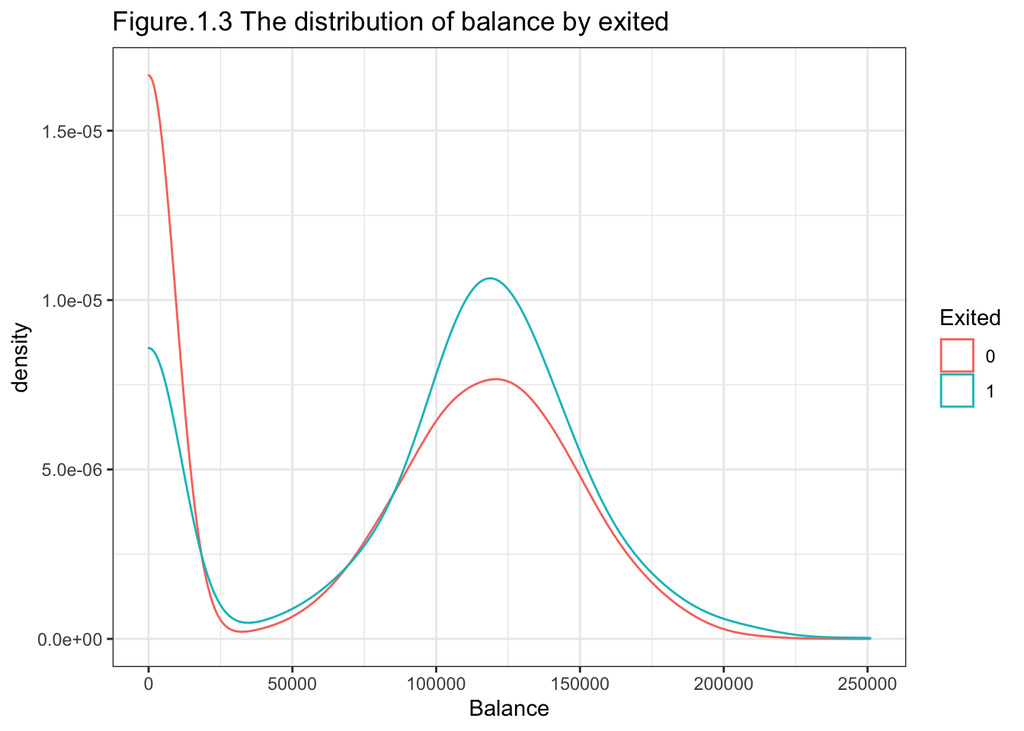

```r
data %>%
  ggplot(aes( Balance, color = Exited )) +
  geom_density() +
  ggtitle("Figure.1.3 The distribution of balance by exited") +
  theme_bw()
```

- Figure 2 indicates that exited customers have a higher mean age than those retained. There is no significant difference in gender between the exited and retained groups.

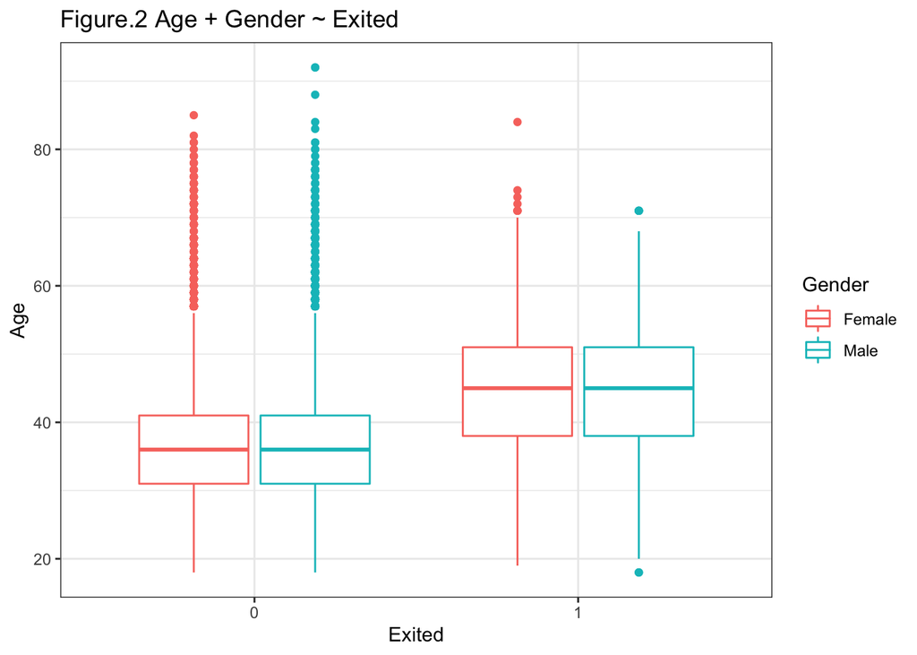

```r
data %>%
  ggplot(aes(x = Exited, y = Age, color = Gender)) +
  geom_boxplot() +
  ggtitle("Figure.2 Age + Gender ~ Exited") +
  theme_bw()
```

- Figure 3 shows the geographic information of the customers. It seems that the proportion of churn is much higher in Germany than that in France.

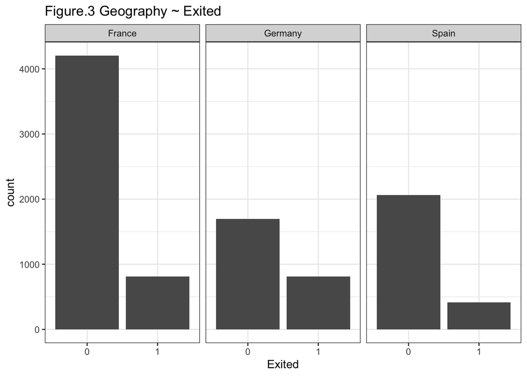

```r
data %>%
  ggplot(aes(x = Exited)) +
  geom_bar() +
  facet_grid(~ Geography) +
  ggtitle("Figure.3 Geography ~ Exited") +
  theme_bw()
```

- Female has a higher rate of churn in this data set.

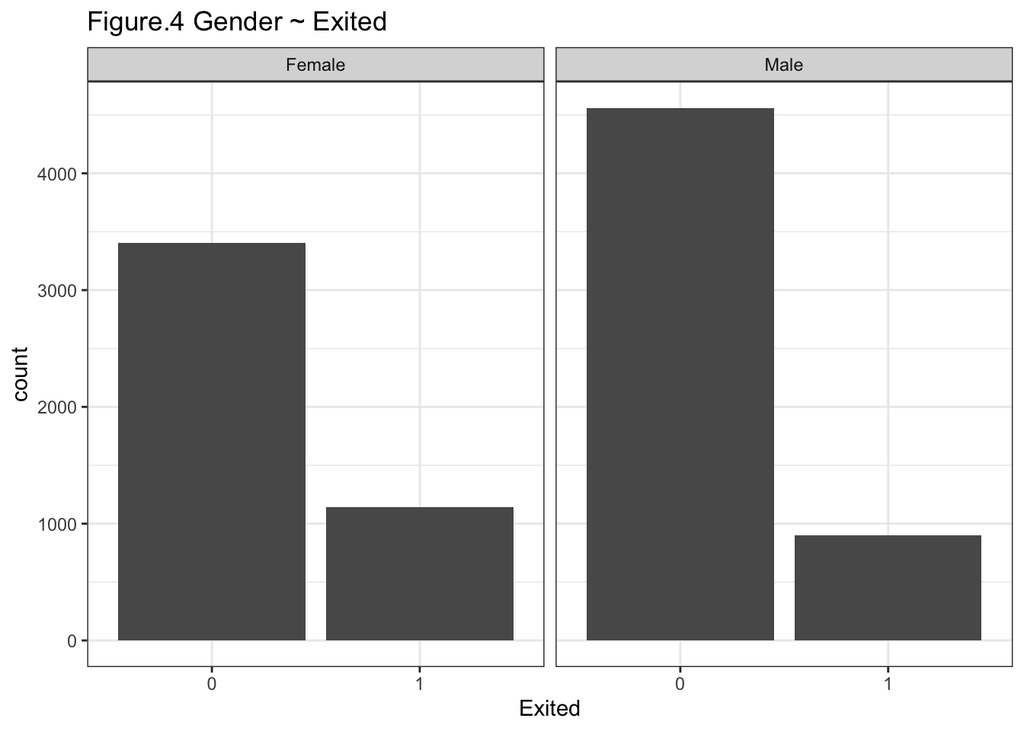

```r
data %>%
  ggplot(aes(x = Exited)) +
  geom_bar() +
  facet_grid(  ~ Gender) +
  ggtitle("Figure.4 Gender ~ Exited") +
  theme_bw()
```

# Model fitting

## R

In this model fitting part, we will fit a logistic regression to the bank churn dataset.

### Setup

We started with a full model with all the predictors.

```r
data = data %>% mutate(Exited = as.factor(Exited),
                       HasCrCard = as.factor(HasCrCard),
                       IsActiveMember = as.factor(IsActiveMember))
# modeling
model1 = glm(Exited ~ ., data = data, family = binomial(link="logit"))
summ(model1)
```

| Observations | 10000 |
| --- | --- |
| Dependent variable | Exited |
| Type | Generalized linear model |
| Family | binomial |
| Link | logit |

| 𝛘²(11) | 1548.43 |
| --- | --- |
| Pseudo-R² (Cragg-Uhler) | 0.23 |
| Pseudo-R² (McFadden) | 0.15 |
| AIC | 8585.36 |
| BIC | 8671.88 |

|  | Est. | S.E. | z val. | p |
| --- | --- | --- | --- | --- |
| (Intercept) | -3.39 | 0.24 | -13.86 | 0.00 |
| CreditScore | -0.00 | 0.00 | -2.38 | 0.02 |
| GeographyGermany | 0.77 | 0.07 | 11.45 | 0.00 |
| GeographySpain | 0.04 | 0.07 | 0.50 | 0.62 |
| GenderMale | -0.53 | 0.05 | -9.70 | 0.00 |
| Age | 0.07 | 0.00 | 28.23 | 0.00 |
| Tenure | -0.02 | 0.01 | -1.70 | 0.09 |
| Balance | 0.00 | 0.00 | 5.13 | 0.00 |
| NumOfProducts | -0.10 | 0.05 | -2.15 | 0.03 |
| HasCrCard1 | -0.04 | 0.06 | -0.75 | 0.45 |
| IsActiveMember1 | -1.08 | 0.06 | -18.64 | 0.00 |
| EstimatedSalary | 0.00 | 0.00 | 1.01 | 0.31 |

Standard errors: MLE

```r
model2 = glm(Exited ~ CreditScore + Geography + Gender + Age + Tenure +
               Balance + NumOfProducts + IsActiveMember + EstimatedSalary,
             data = data,
             family = binomial(link="logit"))
summ(model2)
```

| Observations | 10000 |
| --- | --- |
| Dependent variable | Exited |
| Type | Generalized linear model |
| Family | binomial |
| Link | logit |

| 𝛘²(10) | 1547.86 |
| --- | --- |
| Pseudo-R² (Cragg-Uhler) | 0.23 |
| Pseudo-R² (McFadden) | 0.15 |
| AIC | 8583.92 |
| BIC | 8663.23 |

|  | Est. | S.E. | z val. | p |
| --- | --- | --- | --- | --- |
| (Intercept) | -3.43 | 0.24 | -14.22 | 0.00 |
| CreditScore | -0.00 | 0.00 | -2.37 | 0.02 |
| GeographyGermany | 0.77 | 0.07 | 11.44 | 0.00 |
| GeographySpain | 0.04 | 0.07 | 0.51 | 0.61 |
| GenderMale | -0.53 | 0.05 | -9.70 | 0.00 |
| Age | 0.07 | 0.00 | 28.23 | 0.00 |
| Tenure | -0.02 | 0.01 | -1.72 | 0.08 |
| Balance | 0.00 | 0.00 | 5.15 | 0.00 |
| NumOfProducts | -0.10 | 0.05 | -2.16 | 0.03 |
| IsActiveMember1 | -1.07 | 0.06 | -18.63 | 0.00 |
| EstimatedSalary | 0.00 | 0.00 | 1.02 | 0.31 |

Standard errors: MLE

In model 2, we noticed that `EstimatedSalary` is not significant. So we eliminate `EstimatedSalary` from model 2. Below are the results of the reduced model.

```r
model3 = glm(Exited ~ CreditScore + Geography + Gender + Age + Tenure +
               Balance + NumOfProducts + IsActiveMember,
             data = data,
             family = binomial(link="logit"))
summ(model3)
```

| Observations | 10000 |
| --- | --- |
| Dependent variable | Exited |
| Type | Generalized linear model |
| Family | binomial |
| Link | logit |

| 𝛘²(9) | 1546.83 |
| --- | --- |
| Pseudo-R² (Cragg-Uhler) | 0.23 |
| Pseudo-R² (McFadden) | 0.15 |
| AIC | 8582.95 |
| BIC | 8655.06 |

|  | Est. | S.E. | z val. | p |
| --- | --- | --- | --- | --- |
| (Intercept) | -3.38 | 0.24 | -14.31 | 0.00 |
| CreditScore | -0.00 | 0.00 | -2.38 | 0.02 |
| GeographyGermany | 0.77 | 0.07 | 11.44 | 0.00 |
| GeographySpain | 0.04 | 0.07 | 0.51 | 0.61 |
| GenderMale | -0.53 | 0.05 | -9.71 | 0.00 |
| Age | 0.07 | 0.00 | 28.23 | 0.00 |
| Tenure | -0.02 | 0.01 | -1.71 | 0.09 |
| Balance | 0.00 | 0.00 | 5.16 | 0.00 |
| NumOfProducts | -0.10 | 0.05 | -2.14 | 0.03 |
| IsActiveMember1 | -1.08 | 0.06 | -18.65 | 0.00 |

Standard errors: MLE

### Hosmer-Lemeshow Goodness of Fit Test

When performing the HT test, we need to choose the number of groups g. In practice, Hosmer and Lemeshow’s conclusions from simulations are based on using g > p + 1, where p is the number of covariates in the model. However, there is very little guidance on how to determine g. In this example, we specify g to be 10 for both models. One can easily notice that a small value of g gives us less opportunity to detect mis-specification while a large value of g will cause fragmentary subgroups.

#### HT test for the full model

To perform Hosmer-Lemeshow test in R, we call the `hoslem.test` function from the `ResourceSelection` library.

```r
# Hosmer-Lemeshow Goodness of Fit Test: ---------------------------------------
hl1 = hoslem.test(model1$y, model1$fitted.values, g = 10)
hl1
```

```
##
##  Hosmer and Lemeshow goodness of fit (GOF) test
##
## data:  model1$y, model1$fitted.values
## X-squared = 15.222, df = 8, p-value = 0.05498
```

We have a non-significant p-values for this full model, which means that we have no evidence that the model is fitted poorly.

```r
cbind(hl1$expected, hl1$observed)
```

```
##                    yhat0     yhat1  y0  y1
## [0.0113,0.0471] 965.3959  34.60408 964  36
## (0.0471,0.0695] 941.4907  58.50932 938  62
## (0.0695,0.0939] 918.7260  81.27397 924  76
## (0.0939,0.122]  892.0266 107.97336 893 107
## (0.122,0.153]   862.5575 137.44254 883 117
## (0.153,0.193]   827.5657 172.43425 814 186
## (0.193,0.243]   783.7836 216.21640 793 207
## (0.243,0.315]   723.4961 276.50388 724 276
## (0.315,0.443]   625.7909 374.20910 585 415
## (0.443,0.931]   422.1669 577.83308 445 555
```

The first two columns are the expected numbers of 0’s and 1’s for a given group. The last two columns are the observed numbers of retained and exited customers. We divided the points into ten groups. To better visulize the HL test results, we use the `HLfit` function from the `modEvA` package. The first argument of `HL` is a model object of class “glm”. The `bin.method` argument should be specified from these options, “round.prob” “prob.bins”, “size.bins” , “n.bins” and “quantiles”. The number of groups can be specified via `n.bins`. The default vaule is 10.

```
## Arguments fixed.bin.size, min.bin.size and min.prob.interval are ignored by this bin.method.
```

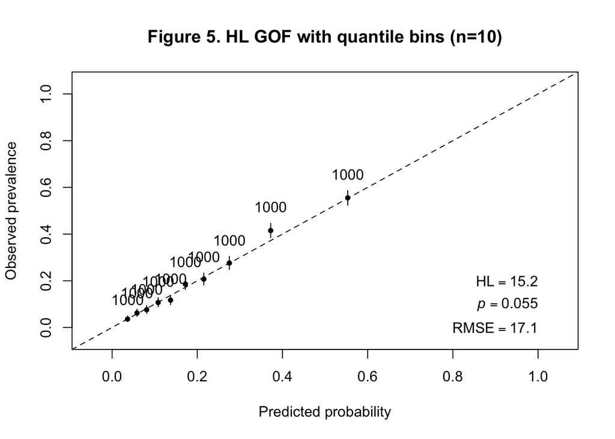

```
## $bins.table
##     BinCenter NBin BinObs    BinPred BinObsCIlower BinObsCIupper
## 1  0.03637642 1000  0.036 0.03460408    0.02533891    0.04949291
## 2  0.05853867 1000  0.062 0.05850932    0.04786185    0.07877995
## 3  0.08126501 1000  0.076 0.08127397    0.06034366    0.09420432
## 4  0.10815732 1000  0.107 0.10797336    0.08852044    0.12782864
## 5  0.13727002 1000  0.117 0.13744254    0.09772900    0.13855747
## 6  0.17207953 1000  0.186 0.17243425    0.16233598    0.21152836
## 7  0.21533536 1000  0.207 0.21621640    0.18228090    0.23345695
## 8  0.27533357 1000  0.276 0.27650388    0.24848731    0.30483816
## 9  0.37228857 1000  0.415 0.37420910    0.38425007    0.44625183
## 10 0.55322253 1000  0.555 0.57783308    0.52357441    0.58610089
##
## $chi.sq
## [1] 15.2215
##
## $DF
## [1] 8
##
## $p.value
## [1] 0.05497894
##
## $RMSE
## [1] 17.07415
```

```r
HLfit(model = model1, bin.method = "quantiles",
      n.bins = 10,
      main = "Figure 5. HL GOF with quantile bins (n=10)")
```

#### HT test for the reduced model

We used the same number of groups in this HT test. The p-value indicates that there is no evidence that the model is poorly fitted.

```r
# Hosmer-Lemeshow Goodness of Fit Test: ---------------------------------------
hl2 = hoslem.test(model3$y, model3$fitted.values, g = 10)
hl2
```

```
##
##  Hosmer and Lemeshow goodness of fit (GOF) test
##
## data:  model3$y, model3$fitted.values
## X-squared = 13.132, df = 8, p-value = 0.1074
```

```
## Arguments fixed.bin.size, min.bin.size and min.prob.interval are ignored by this bin.method.
```

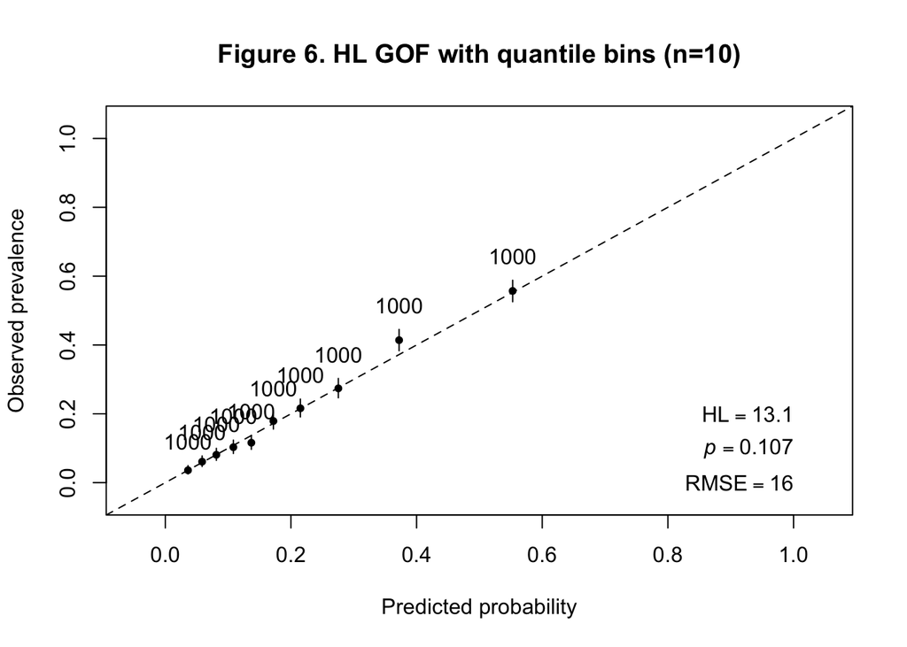

```
## $bins.table
##     BinCenter NBin BinObs    BinPred BinObsCIlower BinObsCIupper
## 1  0.03614128 1000  0.036 0.03467463    0.02533891    0.04949291
## 2  0.05862109 1000  0.061 0.05858295    0.04697788    0.07767077
## 3  0.08126575 1000  0.081 0.08137046    0.06484354    0.09967170
## 4  0.10833209 1000  0.103 0.10813992    0.08485137    0.12352293
## 5  0.13697507 1000  0.116 0.13720219    0.09680596    0.13748675
## 6  0.17208461 1000  0.179 0.17252006    0.15571273    0.20419391
## 7  0.21505172 1000  0.216 0.21635624    0.19086089    0.24282293
## 8  0.27546234 1000  0.274 0.27651333    0.24655555    0.30278182
## 9  0.37215609 1000  0.414 0.37401295    0.38326376    0.44524405
## 10 0.55291492 1000  0.557 0.57762726    0.52558244    0.58808105
##
## $chi.sq
## [1] 13.13151
##
## $DF
## [1] 8
##
## $p.value
## [1] 0.1074043
##
## $RMSE
## [1] 15.98927
```

```r
HLfit(model = model3, bin.method = "quantiles",
      n.bins = 10,
      main = "Figure 6. HL GOF with quantile bins (n=10)")
```

## Stata

### Setup

In Stata, there are built-in functions called [lfit](https://stats.idre.ucla.edu/stata/webbooks/logistic/chapter3/lesson-3-logis%20tic-regression-diagnostics/) and [estat gof](https://www.stata.com/manuals13/restatgof.pdf) for performing Hosmer-Lemeshow test. However, in order to make HL plot for model calibration, we will first install the hl packages from [sealedenvelope](https://www.sealedenvelope.com/).

```
net from https://www.sealedenvelope.com/
net describe hl
net install hl
```

### Loading data

```
import delimited Churn_Modelling_Cleaned.csv
summarize
save churn_data.dta, replace
clear
```

We first load in the data and use `summarize` to produce an overview of the data

```
summarize
```

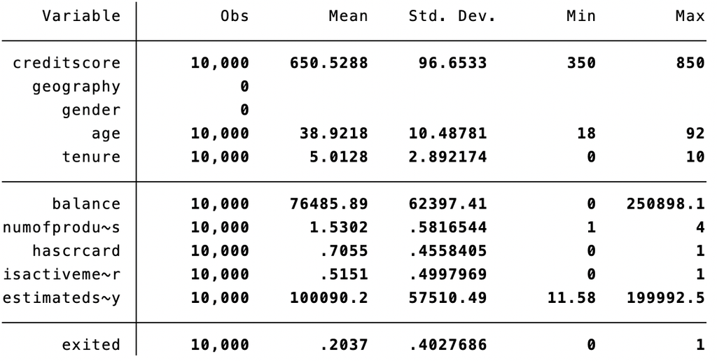

### Fitting logistic model

Before we fit an logistic model, we must notice that stata doesn’t know how to handle string variables for regression. One way to solve this is to use `encode` command. In our case, we use it to convert variables geography and gender.

```
use churn_data
encode geography, gen(geo)
encode gender, gen(sex)
```

Then we use `logit` function to built the logistic regression model with `exited` as response variable and others as predictors.

```
logit exited creditscore i.geo i.sex age tenure balance numofproducts i.hascrcard i.isactivemember estimatedsalary
```

The result is presented below.

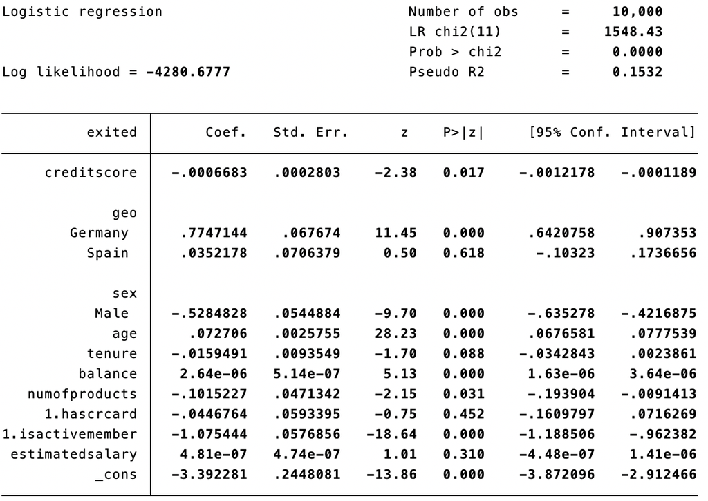

### Hosmer-Lemeshow Test and calibration plot

For a HL test statistics, we can just use `lfit` or `estat gof` commands. In our case, we will use `hl` command that enables us to create calibration plot. Unlike `lfit` or `estat gof`, `hl` command requires us to store predicted value in a variable. We will name it `p_exited` here. Then we can use the command `hl exited p_exited, plot` to obtain the test result and calibration plot. Note that the `, plot` command is optional. Below is the result of the HL test and calibration plot.

```
predict p_exited
hl exited p_exited, plot
```

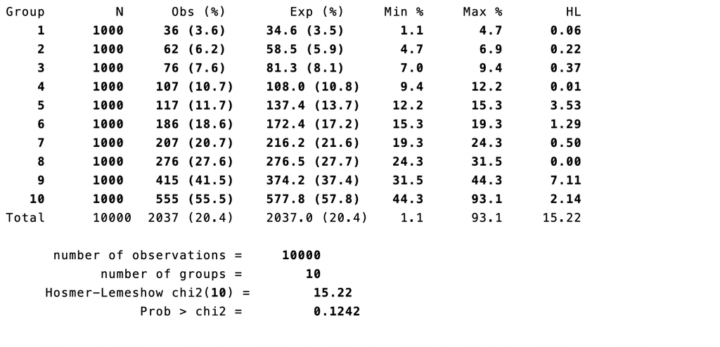

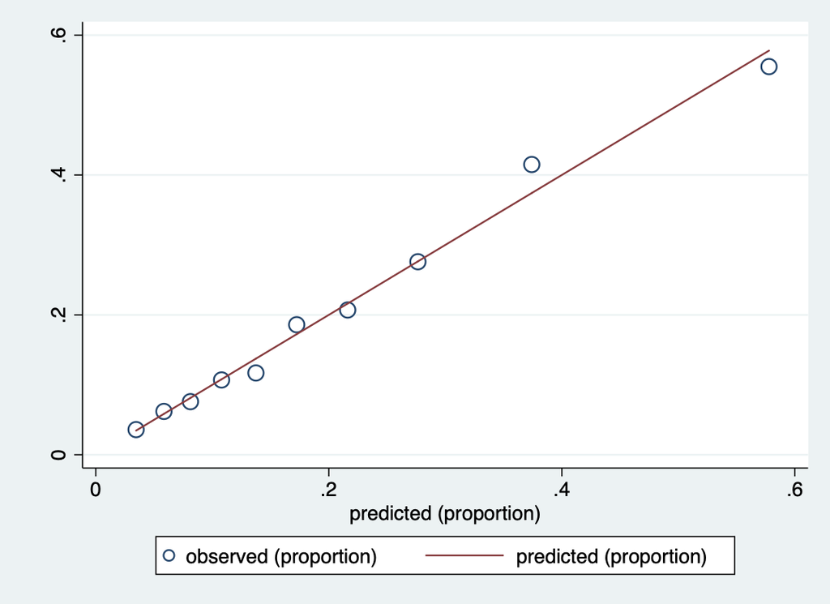

.

We see the the test statistics for the HL test is 0.1242 > 0.05, so we failed to reject null hypothesis, indicating the model is well fitted. The plot also shows that the observed value(bubbles) are well fitted on the line.

### Compare with likelihood based approach(AIC)

We will try to use a likelihood based approach(AIC) and backward elimination method to do variable selection. Then we will construct an optimized model and compare the HL test result with the previous result. The `estat ic` command helps us to find the AIC for the model. The AIC for our current model is 8585.355.

```
estat ic
```

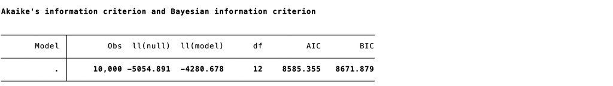

.

```
logit exited creditscore i.geo i.sex age tenure balance numofproducts i.isactivemember estimatedsalary
estat ic
```

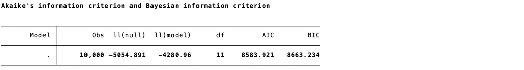

Proceed this procedure, we eliminate EstimatedSalary and the resulting AIC is 8582.953.

```
logit exited creditscore i.geo i.sex age tenure balance numofproducts i.isactivemember
estat ic
```

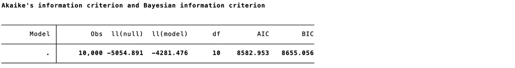

Now we reached our final model and we will then repeat the process of performing HL test and calibration plot again.

We will first present the result.

```
predict np_exited
hl exited p_exited, plot
```

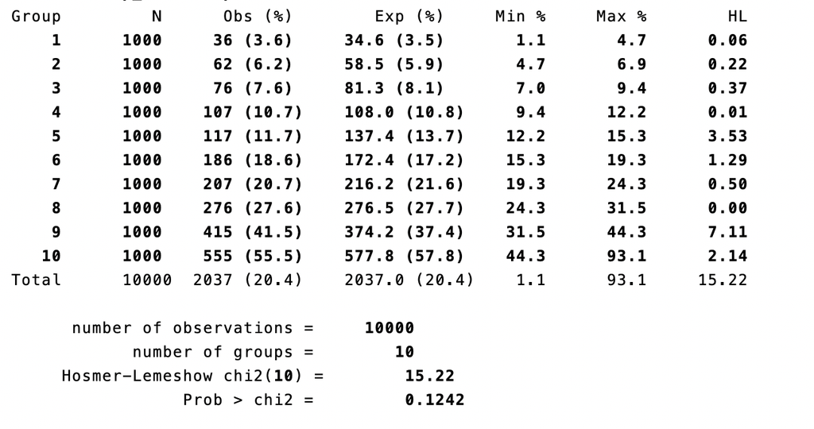

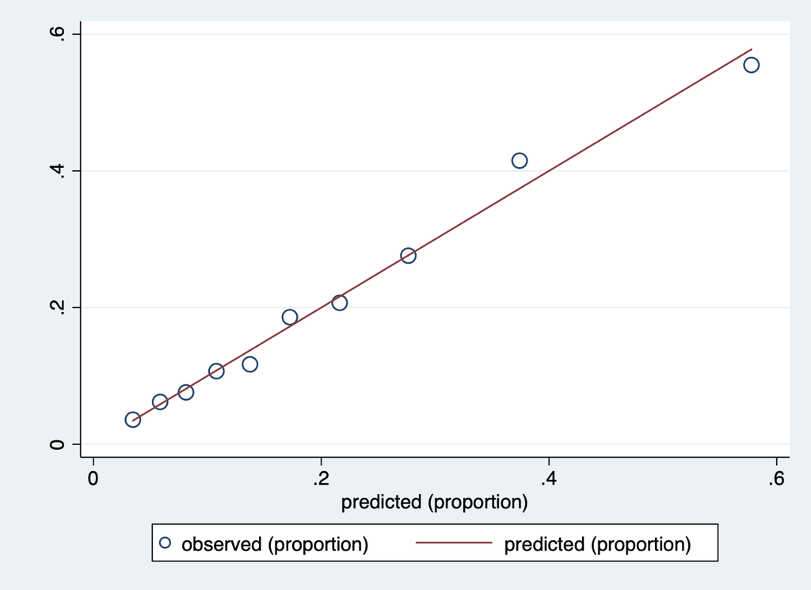

# Conclusion

The logistic regression performed in R and Stata yield the same result. Hosmer and Lemeshow goodness of fit gives same $\chi^2$ statistics. However, the p-values calculated from R and Stata are different. Although both results suggest well fitted models, the p-value calculated from Stata seems to be larger than that calculated from R. The possible explaination for this disparity is that the degree of freedom for HL test in both softwares are different, also for Stata we are using imported sources, the correctness of the calculation is not guaranteed.

We may also perceive some downside of the HL test when we walk through the core examples. It only tells us the goodness of fit of the logistic model but doesn’t provide any constructive suggestions to optimize it. Also, as discussed on [HL test vs. AIC for logistic regression](https://stats.stackexchange.com/questions/18750/hosmer-lemeshow-vs-aic-for-logistic-regression),

> HL test requires arbitrary binning of predicted probabilities and does not possess excellent power to detect lack of calibration. It also does not fully penalize for extreme overfitting of the model.

Hence, when considering model calibration for logistic models, it’s better to consider HL-test as a supplementary technique along with other methods.

# References

[Logistic Model](https://en.wikipedia.org/wiki/Logistic_regression)  
[Hosmer-Lemeshow Test](https://en.wikipedia.org/wiki/Hosmer%E2%80%93Lemeshow_test#Pearson_chi-squared_goodness_of_fit_test)

[STATS 506 Project 2018](https://jbhender.github.io/Stats506/F18/GP/Group5.html)

Some of the html format code was adopted from the source code of the project of group 2 (EunSeon Ahn et al.)

# Acknowledgments

We thank Dr.James Henderson, Yichao Chen, EunSeon Ahn and Erin Susan Cikanek for helpful and constructive instruction and feedback.